# Analyse de Données

Étude immobilière de l’île Mercer (Washington, USA)

## Introduction

Nous allons étudier un jeu de données immobilières. Il s’agit des ventes de logements à King County, compté contenant la ville de Seattle aux États-Unis. Ce jeu de donnée a été utilisé par un cours Coursera, il semblait tout à fait convenir à une introduction à diverses techniques de l’analyse et traitement de données, sachant l’extrême diversité des méthodes à utiliser, même pour des données modestes. Parmi les avantages de cet ensemble de données, déjà mise en forme, pas d’imputation de données nécessaires, peu de facteurs, une application possible d’une régression linéaire sans être obligé d’utiliser des modèles complexes.

L’objectif de ce projet est d’analyser l’ensemble de donnée avant de faire une modélisation par régression linéaire, cette analyse est une étape indispensable pour développer une intuition sur l’ensemble de données, et donc la création de modèle.

### Variables du jeu de données

**id**

Identifiant du logement (ignoré pour l’analyse)

**date**

Date de vente du logement [Date]

**price**

Prix de vente [Continu]

**bedrooms**

Nombre de chambres [Discret]

**bathrooms**

Ratio entre le nombre de salle de bain et de chambre

**sqft-living**

Surface du logement (somme du sous-sol et étages supérieurs) [Continu]

**sqft-above**

Surface du logement située au dessus du sol [Continu]

**sqft-basement**

Surface du logement au niveau du sous-sol [Continu]

**sqft-lot**

Surface du terrain [Continu]

**floors**

Nombre d’étages dans la maison [Discret]

**waterfront**

Vue sur les quais [Binaire]

**condition**

Appréciation de l’état du logement [Factoriel]

**grade**

Évaluation de la qualité de construction du logement [Factoriel]

**yr-built**

Année de construction [Date]

**yr-renovated**

Année de rénovation [Date]

**zipcode**

Zipcode

**lat**

Lattitude [Coordonnées]

**long**

Longitude [Coordonnées]

Petite précision sur le facteur grade. Ce facteur est directement issu de l’administration de King County, en particulier pour la collecte d’impots. Elle établit une classification de 1 à 13 des logements de King County en fonction de la finition du logement. Cela permet d’avoir une vague idée sur la valeur du logement en tant qu’édifice. Il y a donc un ordre entre les niveaux de ce facteur. Néanmoins, ce facteur ne doit pas être pris comme une valeur entièrement objective, car il peut s’agir d’une estimation.

- [1-3] Ne convient presque pas aux standard de construction. A priori une cabane.
- [4] Généralement un édifice de mauvaise qualité ayant vielli. Ne rentre pas dans les standards.
- [5] Peu cher et peu travaillé. Petit et simple.
- [6] Plus petite catégorie qui est aux normes. Matériaux de mauvaise qualité, simplicité.
- [7] Construction normale que l’on rencontre sur un terrain habité.
- [8] Construction un peu mieux que la moyenne. Meilleurs matériaux dans les finitions.
- [9] Meilleure architecture, de bonnes conception et qualité d’éxécution.
- [10] Les habitations de ce type sont celles de qualité supérieure, meilleur finition, plus spacieuse et un meilleur agencement des pièces
- [11] Conception personnalisée et finitions de qualité supérieure, avec ajout de mobilier en bois massif, de mobiliers fixatif dans les salles de bains et agréments de luxe.
- [12] Conception personnalisée et excellents éxécutants. Tous les matériaux sont de qualités supérieurs, et toutes les commodités sont présentes
- [13] Généralement, conception et construction personalisées. Proche du niveau du manoir. Important travail pour les cuisines. Grande quantité de plancher en bois et de marbre. Grandes entrées.

### Restriction à Mercer Island

L’île Mercer fait partie des 100 unités territoriales les plus riches de l’état de Washington. Elle est reliée à la terre qui l’entoure par une voie routière la traversant. On peut l’étudier comme un microsome étant donné le lac qui la sépare de la terre. Comparé à Vashon Island qui ne possède pas de liason terrestre, elle est dynamique et urbanisée.Au sein du jeu de données complet, on peut noter de très grandes disparités territoriales qui ont un impact direct sur le type d’habitation et leurs valeurs. En choisissant un ensemble géographiquement homogène et bien plus petit, on espère pouvoir avoir des conclusions plus précises et faciles à découvrir. Cela doit être vu comme une première étape à l’analyse du jeu de données complet, que l’on ne peut pas mener à cause de contraintes temporelles et manque d’expérience.

## Sommaire

### Variables continues

|  | Minimum | 1er Quartile | Médiane | Moyenne | 3e Quartile | Maximum |
| --- | --- | --- | --- | --- | --- | --- |
| price | 500000.000 | 822000.00000 | 993750.0000 | 1.194230e+06 | 1385500.00000 | 5300000.0000 |
| bathrooms | 1.000 | 2.25000 | 2.5000 | 2.716312e+00 | 3.25000 | 6.7500 |
| sqft_living | 820.000 | 2260.00000 | 3020.0000 | 3.106833e+03 | 3650.00000 | 9640.0000 |
| sqft_lot | 3700.000 | 9870.25000 | 11951.5000 | 1.370446e+04 | 15740.50000 | 92347.0000 |
| sqft_above | 770.000 | 1692.50000 | 2265.0000 | 2.474330e+03 | 3180.00000 | 5770.0000 |
| sqft_basement | 0.000 | 0.00000 | 535.0000 | 6.325035e+02 | 1100.00000 | 4820.0000 |
| lat | 47.526 | 47.54195 | 47.5625 | 4.755985e+01 | 47.57597 | 47.5934 |
| long | -122.251 | -122.23200 | -122.2250 | -1.222256e+02 | -122.21600 | -122.2040 |

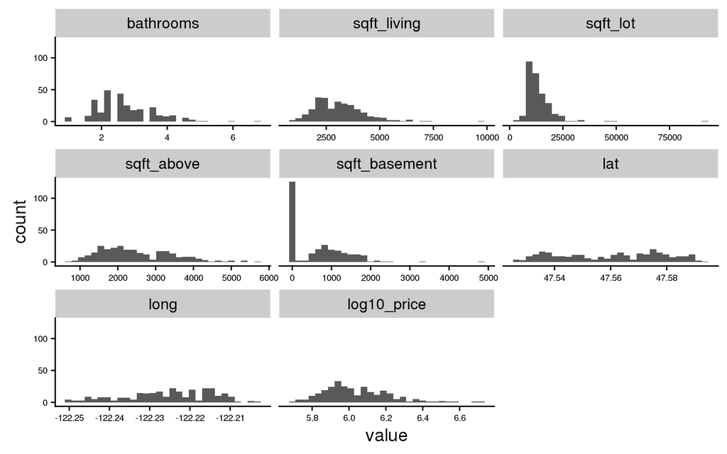

On trace les histogrammes des variables continues,on a le ratio chambre/salle de bains et on observe qu’il y a principalement 2 à 4 fois plus de chambres que de salles de bain. La surface de logement est surtout autour de 2500 feets, la surface du terrain se situe au dessous de 25000, la surface des étages est situé entre 1000 et 3000 puis 3000 et 4000 surement du au nombre d’étages.

### Variables factorielles ou discrètes

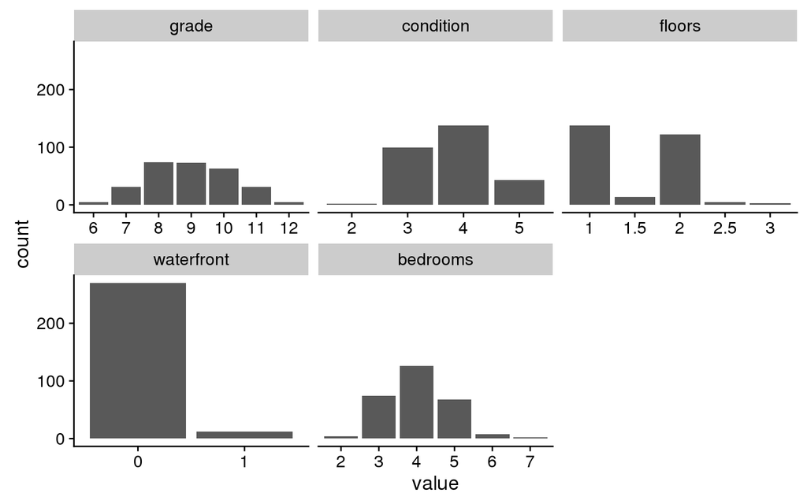

### Variables temporelles

On a trois variables temporelles, l’année de construction et la date de vente et l’année de rénovation, lorsqu’il y en a eu.

|  | Minimum | 1er Quartile | Médiane | Moyenne | 3e Quartile | Maximum |
| --- | --- | --- | --- | --- | --- | --- |
| yr_built | 1916-01-01 | 1960-01-01 | 1968-01-01 | 1971-06-22 | 1980-01-01 | 2015-01-01 |
| date | 2014-05-06 | 2014-06-30 | 2014-09-22 | 2014-10-18 | 2015-02-23 | 2015-05-12 |

Les valeurs manquantes représentent les maisons qui n’ont pas été rénovées.

|  | Minimum | 1er Quartile | Médiane | Moyenne | 3e Quartile | Maximum | Valeurs Manquantes |
| --- | --- | --- | --- | --- | --- | --- | --- |
| yr_renovated | 1970-01-01 | 1990-01-01 | 2000-01-01 | 1996-01-01 | 2005-01-01 | 2012-01-01 | 249 |

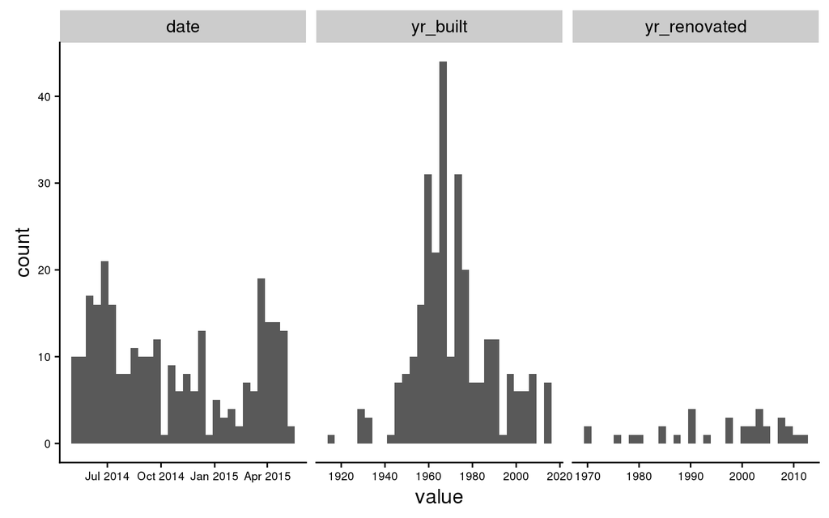

On peut voir que les maisons ont été construites entre 1940 et 1980, et que lorsqu’il y a eu des rénovations c’était équitablement réparti à partir de 1980. Les ventes se situent en plusieurs périodes: Juillet, Novembre/Décembre et Avril.

## Répartition géographique

On trace à présent toutes nos données en fonction de leur position sur l’île. On peut voir que tout est environ équitablement réparti, les maisons les plus luxueuses (nombre de salle de bains, superficie, prix de vente) sont situés en bord d’île.

[figure not shown]

[interactive chart not shown]

## Inégalités

On trace la courbe de Lorenz qui permet de visualiser les inégalités de répartitions de richesses globale. On rappelle que l’indice de Gini des revenu en France est de environ 0.3, et pour les pays les plus égalitaires de 0.2.

Le coefficient de Gini montre qu’il y a une certaine homogénéité des logements. Ce qui est assez intuitif puisqu’il s’agit d’une des îles les plus riches des Etats Unis. On peut dire que tout le monde est riche même si certains le sont davantage que d’autres.

### Valeur

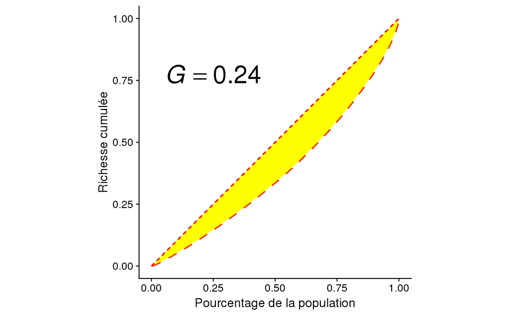

### Surface habitée

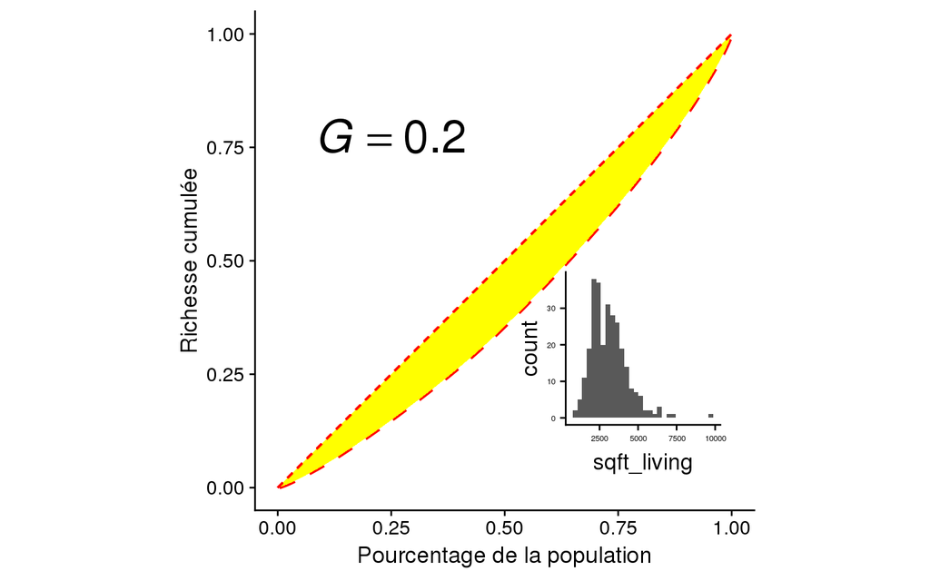

### Surface terrain

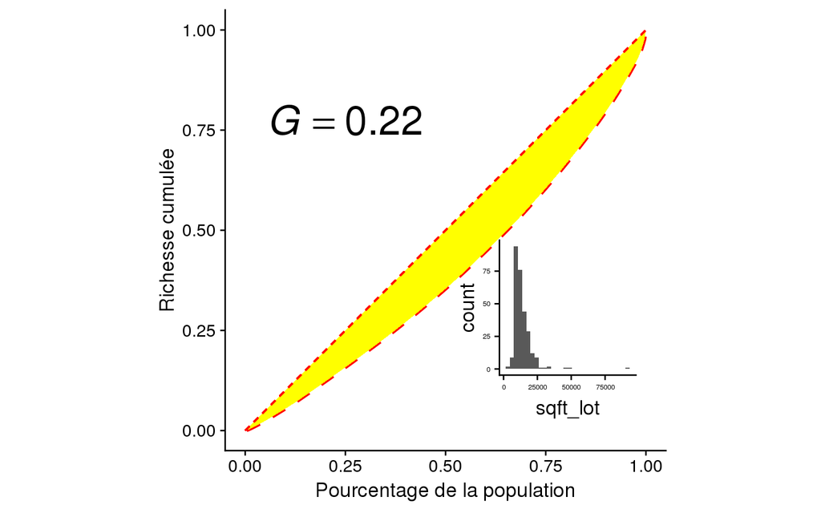

## Liens entre prix et caractéristiques du logement

### Surface habitable

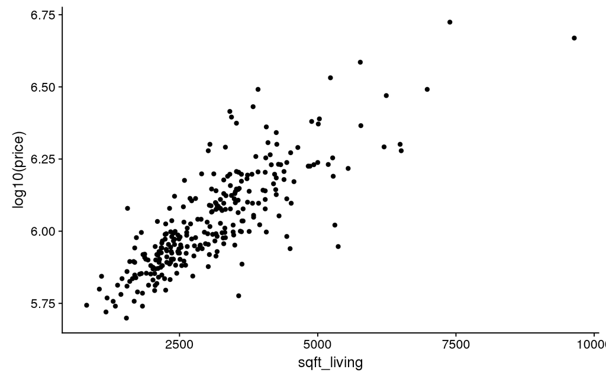

La surface habitable semble grandement expliquer le prix. On a presque (pour les petits prix au moins) un lien linéaire entre surface habitable et log décimal du prix.

### Utilitaires

#### Salles de bain

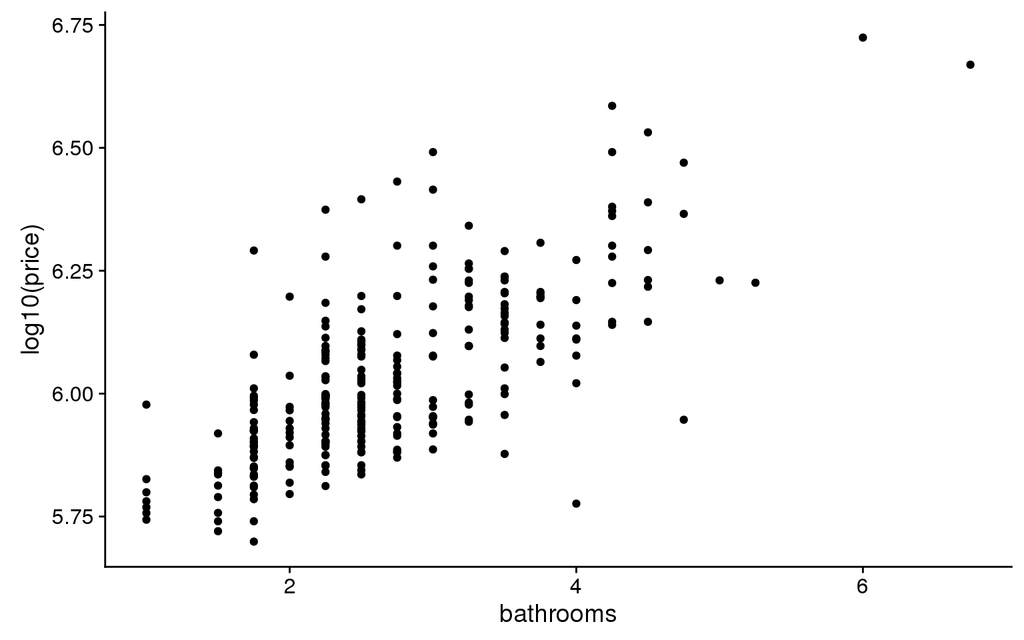

Les maisons dotés de davantage de salles de bain auront une valeur plus grande.

#### Salles à coucher

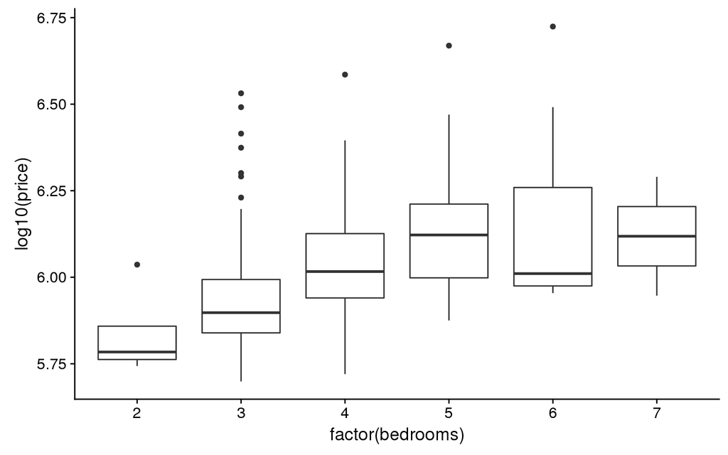

Il en va de même pour le nombre de chambre.

### Audit

#### Grade

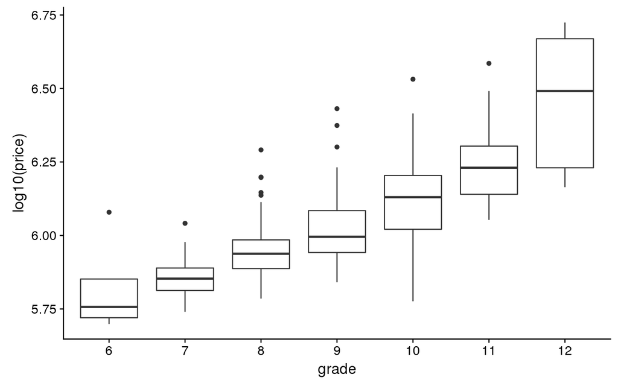

Les maisons jugées luxueuses vont être vendues généralement plus chères que celles qui sont plus austères.

### Temps

#### Année de construction

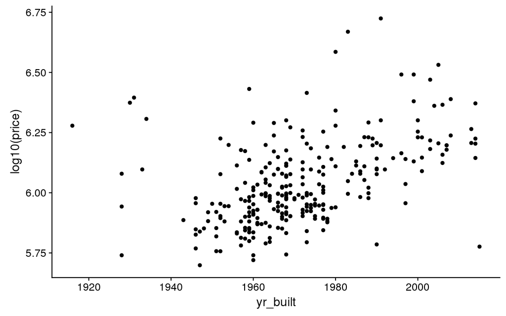

Comme attendue, l’année de construction joue un rôle dans la valeur du logement. Plus ce dernier est ancien, moins il est valorisé.

#### Année de rénovation

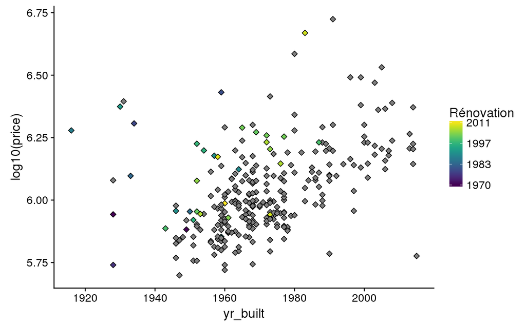

On constate que les logements rénovés ont tendance à être plus valorisée que les logements non rénovées. Mais on ne sait pas si cette interaction est dû à un facteur commun ou bien à un effet direct (il est possible que les logements soit rénovés parce qu’il possède déjà de la valeur, et non l’inverse).

## Liens entre surface et caractéristiques

### Surface habitée

#### Chambre à coucher

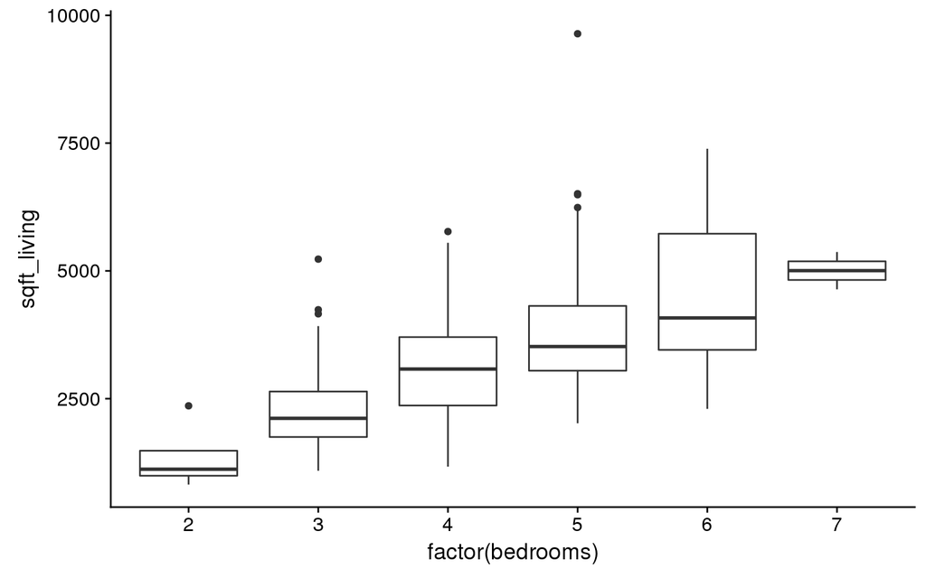

Il y a un lien assez naturel entre le nombre de chambres à coucher et la surface habitable.

#### Grade

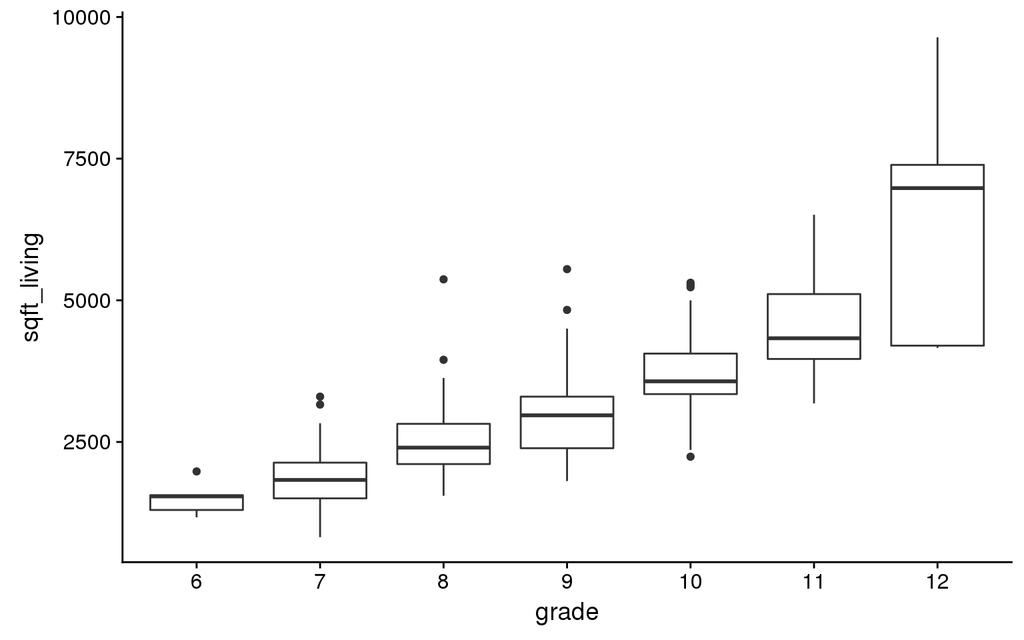

De même, les grandes maisons sont celles qui ont tendance à être luxueuses.

## Analyse en Composantes Principales sur les variables continues

### Tableaux des corrélations

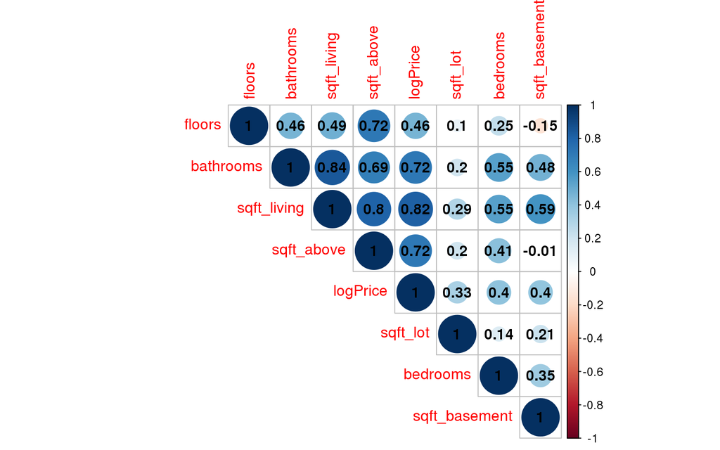

On peut remarquer des groupes de variables assez corrélées entre elles. L’ACP va nous fournir un résultat plus géométrique.

### Projection des variables sur le plan d’inertie maximum

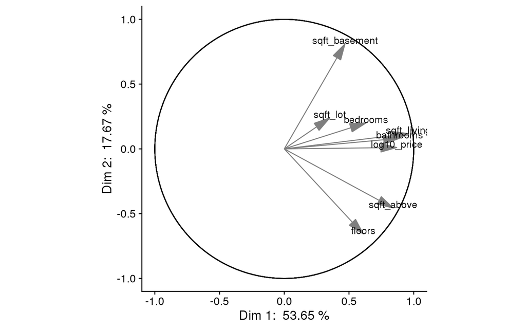

On observe trois groupes de variables:

1. - sqft_basement
2. - log10_price
   - sqft_living
   - bathrooms
3. - sqft_above
   - floors

On constate que le premier axe de l’ACP peut être assimilé à l’une des variables du groupe 2, en particulier le log10_price.

Le pourentage d’inertie du deuxième axe est trop faible pour fournir des interprétations pertinentes. Puisque, $sqft\_basement$ a le plus de contribution on peut comprendre que cette axe est très lié au caractéristiques du sous-sol.

## Facteur significatifs

On procède à une régression linéaire sur le log décimale du prix suivant une sélection de variables considérées significatives (stepwise AIC).

À partir de notre recherche du meilleur modèle linéaire, on conclut que les variables qui ont le plus d’influence sur le prix sont :

- la surface habitable
- la surface aux étages supérieures
- le nombre de chambres à coucher
- l’état du logement
- la date de vente
- la vue sur les quais
- la qualité de l’estimation
- le grade
- l’année de rénovation (minimum entre date de contruction et rénovation)
- la date de vente

On remarque par exemple que le ratio de salles de bain sur le nombre de chambre n’y figure pas. C’est à cause d’une redondance possible avec la surface habitable (voir le graphe de l’ACP).

Ci-dessous, la valeur des résidus de notre modèle géographiquement. On remarque que ce dernier peut déjà estimer la valeur du logement de manière précise (entre la moitié et le double de l’estimation). Par ailleurs, 85% des logements possèdent un prix qui est compris entre 80% et 125% de l’estimation.

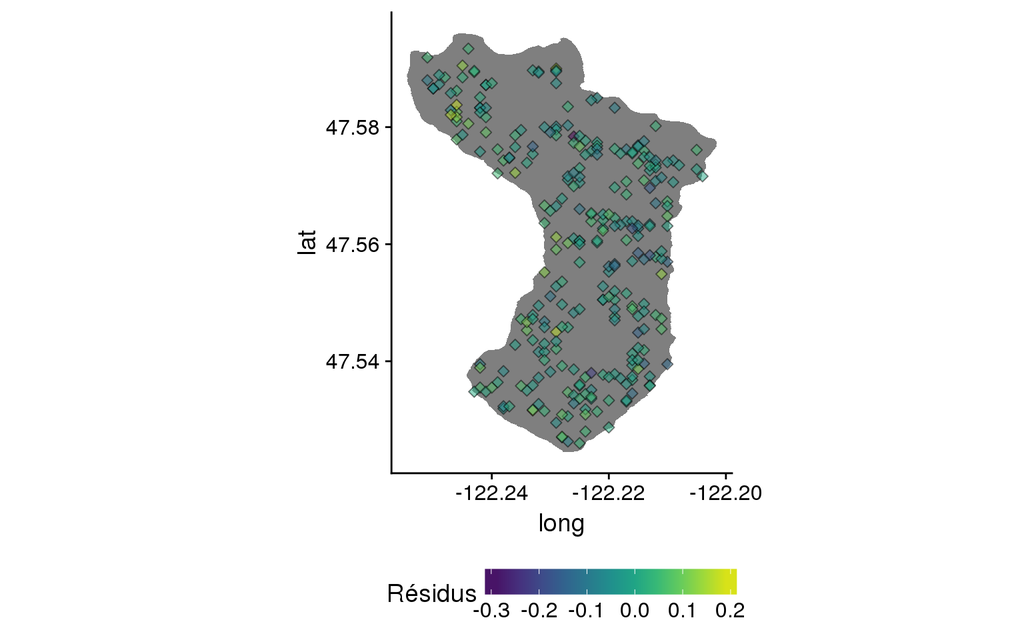

Robert Dazi, Samuel Amoyal et Arnaud Kazemi